# drawR

Amanda Yumi Ambriola

16/02/2021

# Configurando e instalando as bibliotecas no python:

Instalar bibliotecas: eeg_positions No terminal, instalar python3 -m pip install eeg_positions, python3 -m pip install mne

Chamar as bibliotecas no R. O reticulate ajuda a se livrar do Pandas, tidyverse é pra complicar sua vida ao entender o código:

Carrega os pontos das coordenadas:

```python
import matplotlib.pyplot as plt
plt.switch_backend('agg')
from eeg_positions import get_elec_coords, plot_coords
```

## Visualização gráfica no 2D

Seleciona as coordenadas e tipo de visualização no 2D:

```python
coords = get_elec_coords(
    system="1010",
    dim="2d",
)
```

Exibe o head dos canais que foram selecionados:

```python
# `coords` is a pandas.DataFrame object. Imprime algumas:
coords.head()
```

```
##   label         x         y
## 0   AF7 -0.427044  0.587853
## 1   AF8  0.427044  0.587853
## 2   AFz  0.000000  0.509510
## 3    C1 -0.158372  0.000000
## 4    C2  0.158372  0.000000
```

Faz o plot das coordenadas no mapa:

```python
fig, ax = plot_coords(
    coords, scatter_kwargs=dict(color="green"), text_kwargs=dict(fontsize=10)
)

ax.axis("off")
```

```
## (-1.6, 1.6, -1.6, 1.6)
```

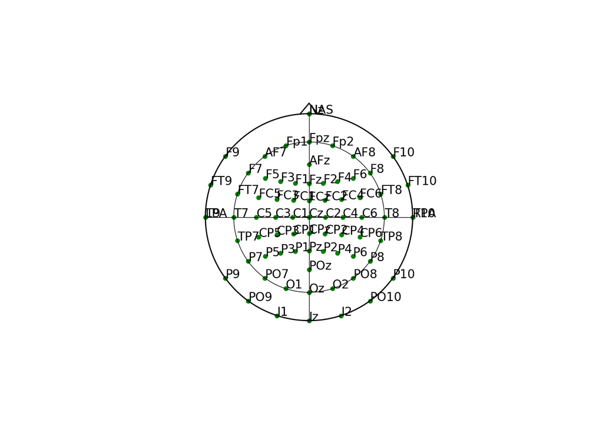

```python
fig
```

## Visualização gráfica no 3D:

Obs: Ainda está ruim mas é porque o matplotlib está incompatível com o ‘eeg_positions’. Se não consertar o pacote, vou tentar configurar manualmente a escala pras cabeças não terem formato de ovo.

Seleciona e plota as coordenadas e tipo de visualização no 3D:

```python
import matplotlib.pyplot as plt
plt.switch_backend('agg')
from eeg_positions import get_elec_coords, plot_coords

coords = get_elec_coords(system="1020", as_mne_montage=True)

fig = coords.plot(kind="3d")
```

```
## Creating RawArray with float64 data, n_channels=21, n_times=1
##     Range : 0 ... 0 =      0.000 ...     0.000 secs
## Ready.
```

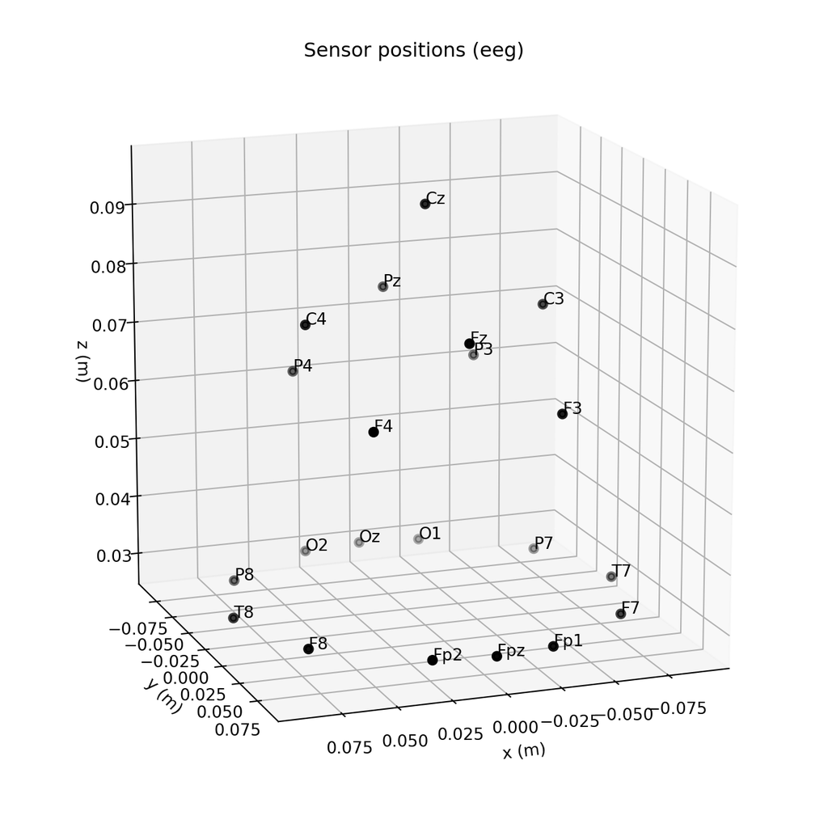

```python
fig.gca().view_init(azim=70, elev=15)
fig
```

## Convertendo coordenadas de fNIRS para o mapa cerebral

Para os canais de fnirs, eu criei um csv com os dados do canal de uma montagem específica de touca fNIRS e entre quais localizações do sistema 10-10 do EEG eles se localizam num csv (fnirs_eeg.csv). O conteúdo desse csv é uma tabela com: (num_canal_fnirs - primeiro ponto - segundo ponto).

```r
fnirs_data = as.data.frame(read_csv2("fnirs_eeg.csv"))
head(fnirs_data)
```

```
##   channel eeg1 eeg2
## 1      V1  Fp1  AF7
## 2      V2  AF7   F5
## 3      V3  Fp1  AF3
## 4      V4  AF3   F5
## 5      V5  Fp2  AF8
## 6      V6  AF8   F6
```

Mostra o ‘head’ dos dados armazenados de coordenadas de EEG:

```r
source_python("get_eeg_coords.py")
coords <- get_eeg_coords()
head(coords)
```

```
##   label          x         y
## 1   AF1 -0.1024726 0.5138924
## 2  AF10  0.5878000 0.8090000
## 3 AF10h  0.5020754 0.6910239
## 4  AF1h -0.0511622 0.5105483
## 5   AF2  0.1024726 0.5138924
## 6  AF2h  0.0511622 0.5105483
```

Identifica as coordenadas cartesianas dos canais de EEG e calcula o ponto médio entre eles para pegar a localização dos canais de fNIRS e armazena num csv.

```r
N <- nrow(fnirs_data)
X = matrix(NA, nrow = N, ncol = 2)
Y = matrix(NA, nrow = N, ncol = 2)
for(ii in 1:2)
{
  for(jj in 1:N)
  {
    idx = which(coords$label == fnirs_data[jj, 1+ii])
    X[jj, ii] = coords$x[idx]
    Y[jj, ii] = coords$y[idx]
  }
}
X = 0.5*(X[,1] + X[,2])
Y = 0.5*(Y[,1] + Y[,2])

fnirs_coords = data.frame(label = fnirs_data$channel,
                          x = X,
                          y = Y
)
write_csv(fnirs_coords, "./coords_fNIRS.csv")
```

Agora de volta para o código em Python, utiliza a biblioteca eeg_positions para a partir das posições salvas no csv plotar no gráfico 2D:

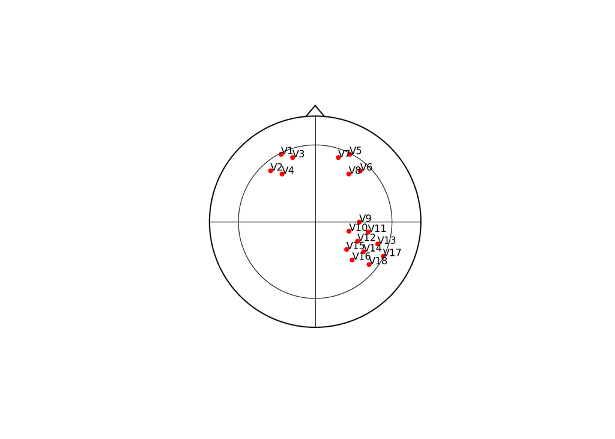

```python
import matplotlib.pyplot as plt
import pandas as pd
plt.switch_backend('agg')

from eeg_positions import get_elec_coords, plot_coords
coords = pd.read_csv("coords_fNIRS.csv")

fig, ax = plot_coords(
coords, scatter_kwargs=dict(color="red"), text_kwargs=dict(fontsize=8)
)
aux = ax.axis("off")
fig
```